# Project 1: Filtered Historical Simulation

*(informally) due Thursday, March 8, 2018

## Value-at-Risk

Value-at-Risk (*VaR*) asks the question: “What loss level is such that we are X% confident it will not be exceeded in *N* business days”.

In this assignment you will calculate the VaR of a single long position in the S&P 500. You will need to calculate a $10$-day $99\%$ VaR.

## Filtered Historical Simulation

In order to carry out the analysis for our VaR calculation we require a predictive distribution. We will create our predictive distribution via a semi-parametric computational method called *Filtered Historical Simulation* (FHS).

In FHS we begin with a GARCH model (we will use a GARCH(1,1)) model:

$$\hat{\sigma}_{t+1}^{2} = \hat{\omega} + \hat{\alpha} \hat{r}_{t}^{2} + \hat{\beta} \hat{\sigma}_{t}^{2}$$

FHS assumes that innovations are drawn from the standardized empirical return distribution. In other words, we assum the standardized innovations are given by

$$\varepsilon_{t} = \frac{r_{t}}{\hat{\sigma}_{t}}$$

Where $r_{t}$ is the historical log return and $\hat{\sigma}$ is the estimated GARCH daily standard deviation at time $t$. Assume that initial values of $\hat{\sigma}_{0}$ and $r_{0}$ are given as the most recently observed quantities on the day prior to the analysis (i.e. these will be the work “data”).

To get the simulation pricess started we first compute the day-1 GARCH daily volatility as:

$$\hat{\sigma}_{1}^{2} = \hat{\omega} + \hat{\alpha} \hat{r}_{0}^{2} + \hat{\beta} \hat{\sigma}_{0}^{2}$$

Then the first simulated log return on day 1 is computed as $\hat{r}_{r} = \varepsilon_{1} \hat{\sigma}_{1}$ where a value for $\varepsilon_{1}$ is chosen by the statistical bootstrap from the sample of historical standardized innovations.

From here we simulate subsequent days as:

$$\hat{\sigma}_{t+1}^{2} = \hat{\omega} + \hat{\alpha} \hat{r}_{t}^{2} + \hat{\beta} \hat{\sigma}_{t}^{2} \quad \mbox{with} \quad \hat{r}_{t} = \varepsilon_{t} \hat{\sigma}_{t} \quad \mbox{for} \quad t = 1, \ldots, h$$

where $\varepsilon_{t}$ is drawn independently of $\varepsilon_{t}$ in the boostrap. The $h$-day simulated log return will then become $\hat{r}_{1} + \hat{r}_{2} + \cdots + \hat{r}_{h}$.

### Simulation Details

First estimate the GARCH(1,1) model using the `rugarch` package.

```r
require(rugarch)
setwd("C:\\Users\\maddi\\Desktop\\Fin6320\\data")
rawData <- read.csv("SP500.csv", header = T)
```

Now carry out the FHS method.

```r
ret <- diff(log(rawData$SP500))

sp <- ugarchspec()
fit <- ugarchfit(ret, spec = sp)
w <- coef(fit)[[4]]
a <- coef(fit)[[5]]
b <- coef(fit)[[6]]
theta <- c(w, a, b)

n <- length(ret)
r.init <- ret[n]
v.cond <- as.numeric(fitted(fit))
v.init <- v.cond[n]
c(r.init, v.init)
```

```
## [1] 0.00567115 0.00100266
```

```r
resid <- ret / v.cond
tail(resid)
```

```
## [1]   33.894319   39.429853 -111.094971  -28.059060  -10.246476    5.656104
```

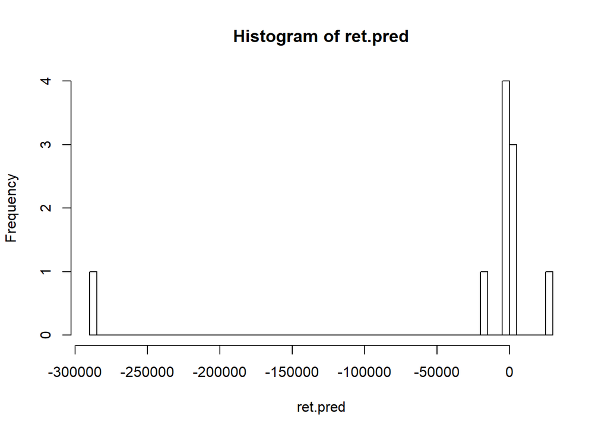

```r
reps <- 10
steps <- 10
paths <- matrix(0, nrow = reps, ncol = steps + 1)
paths[,1] <- r.init

for(i in 1:reps)
{
  z <- sample(resid, size = steps, replace = T)
  sigma <- v.init
  for(j in 2:(steps + 1))
  {
    sigma <- sqrt(w + a * (paths[i, j-1] * paths[i, j -1]) + b * (sigma * sigma))
    paths[i,j] <- z[j - 1] * sigma
  }
}

ret.pred <- apply(paths[,2:(steps + 1)], 1, sum)
hist(ret.pred, breaks = 50)
```

And finally, calculate the VaR for each value of $\alpha$.

```r
alpha <- c(0.01, 0.05, 0.1)

VaR <- quantile(ret.pred, probs = alpha)

#Table containing VaR for each alpha
as.data.frame(VaR, responseName = "alpha")
```

```
##            VaR
## 1%  -264929.86
## 5%  -167850.62
## 10%  -46501.57
```